# Domain specifity of collocations in Russian academic texts

### Authors: Anna Dmitrieva, Aleksandr Klimov

### Data: [full CAT collocation lists](https://drive.google.com/drive/folders/1mIZM04zERm6SnvUZ3pLQPXk71mGAZ3jr), domain-wise collocation lists

Our data consists of a few lists of collocations of Russian academic texts gathered from the Russian Corpus of Academic Texts (CAT). There are complete lists of word ngrams (from unigrams to sixgrams) obtained from the whole corpus and lists obtained for each domain. For this research, we used complete trigrams and fivegrams lists and trigrams and fivegrams lists of each domain, so 9 datasets alltogether. Each list includes the ngrams, their frequency (raw and relative), POS-tagset and some collocation metrics: PMI, likelihood ratio and t score computed for each ngram.

Please note that I (Anna, the maker of CAT collocation lists) accidently typed “raw frequency” instead of “relative” in the datasets. Yes, in all of them.

### Project description

This research is focused on two questions:

Question 1: Are the most significant collocations domain-specific? Hypothesis 0: top collocations are the same for all domains Hypothesis 1: top collocations are different for each domain

Question 2: Do collocation metrics actually correlate with the frequency and, if yes, how strong is the correlation? Hypothesis 0: PMI, t score and likelihood ratio do not correlate with the ngram frequency Hyphothesis 1: there is a correlation between collocation metrics and frequency

Let’s start with the second question.

### Question 2

The reason we are discussing this topic is that all collocation metrics used in this research are believed to be biased towards frequency, t score and likelihood ratio having a direct relation with frequency and PMI having an inverse relation with it. In order to pick the most significant collocations from the list we had to check how strong these correlations might in fact be, and see if it’s possible that we end up just taking the most frequent (or, with PMI, infrequent) word sequences out of the lists.

At first, we tried to plot the dispersion of all collocation measures over frequency. In order to be able to plot all three measures at once, we turned all variables to percentiles, so they will range from 0 to 1. Those modified variables are not used in correlations and models.

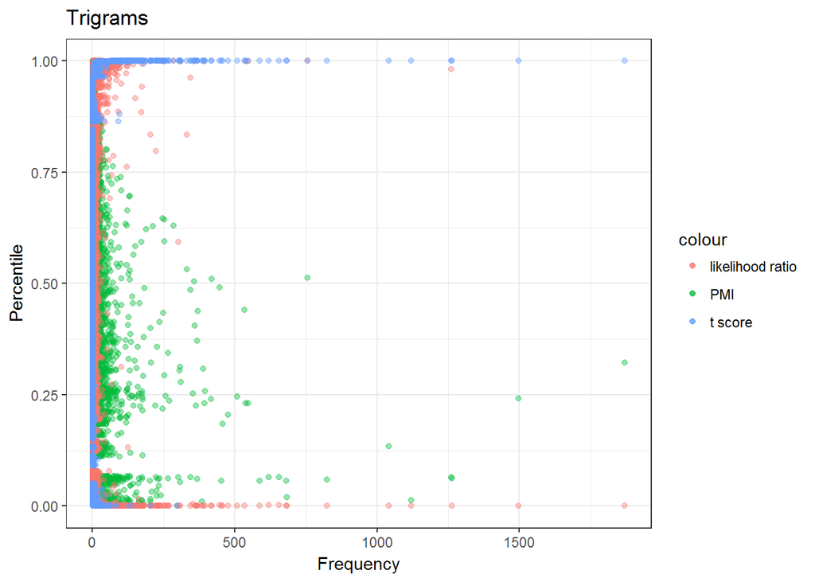

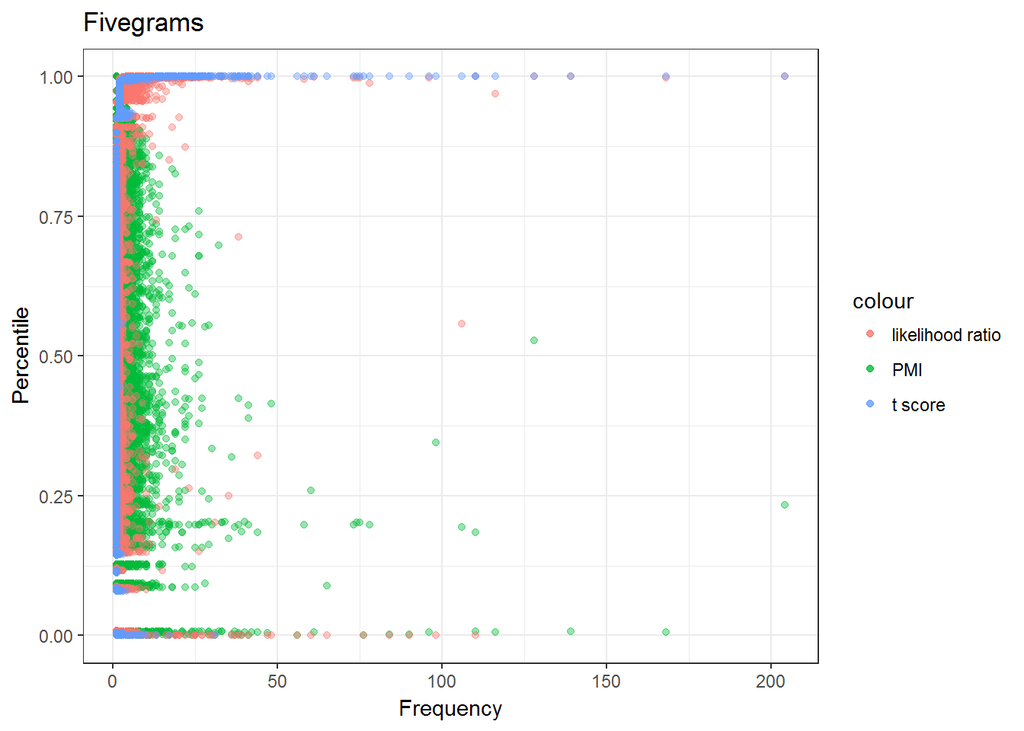

As can be seen, there might be a direct relation between t score and likelihood ratio and frequency and an inverse relation between frequency and PMI, but we have to check if those correlations are actually present, and, if yes, how strong they are. Let’s start with trigrams.

#### Trigrams (complete corpus list, sample size=50000)

[output not shown]

```
## 'data.frame':    50000 obs. of  8 variables:
##  $ X               : int  1140939 174348 584706 374519 659143 416475 79808 928304 622175 857802 ...
##  $ frequency       : num  1 1 1 2 1 1 1 1 1 1 ...
##  $ likelihood.ratio: num  24.85 19.54 17.18 20.45 6.97 ...
##  $ ngram           : Factor w/ 1197006 levels "- - -","- - ,",..: 936936 614300 453937 264240 423004 324439 3806 963448 487435 823278 ...
##  $ pmi             : num  18.65 15.43 13.39 8.59 5.03 ...
##  $ raw.frequency   : num  4.04e-07 4.04e-07 4.04e-07 8.08e-07 4.04e-07 ...
##  $ t.score         : num  1 1 1 1.411 0.969 ...
##  $ tag             : Factor w/ 2218 levels "- - -","- - ,",..: 1704 609 756 877 1851 1706 120 1548 1843 685 ...
```

Checking the variables distribution in order to decide on the correlation tests:

```
##
##  One-sample Kolmogorov-Smirnov test
##
## data:  unique(tri_samp$t.score)
## D = 0.32455, p-value < 2.2e-16
## alternative hypothesis: two-sided
```

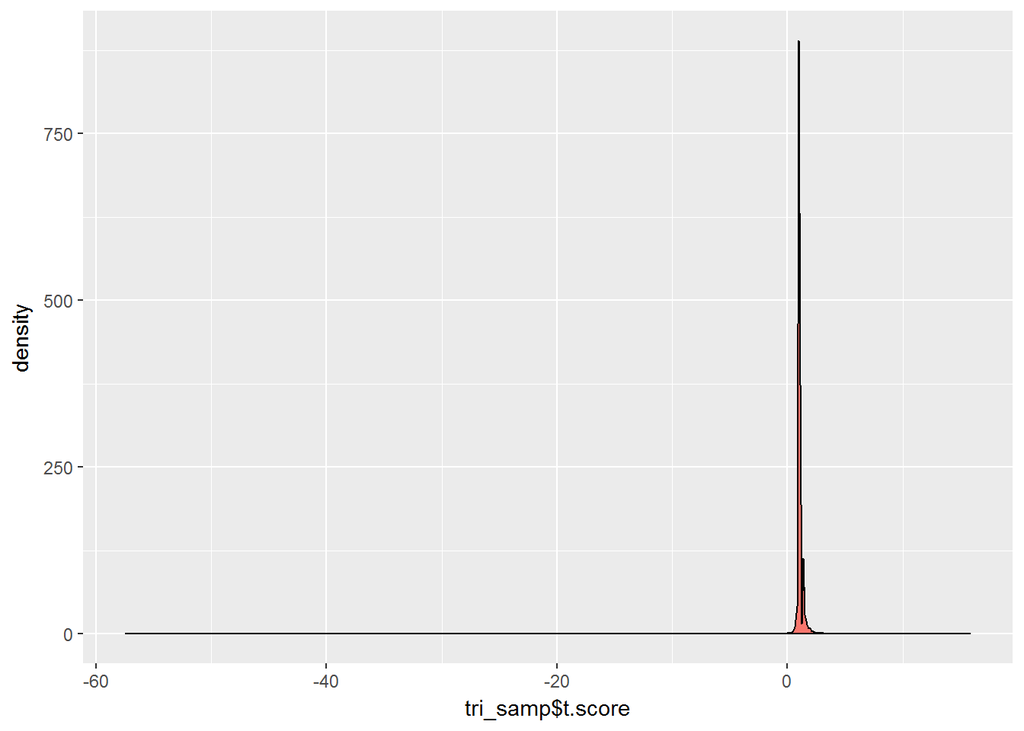

```
##
##  One-sample Kolmogorov-Smirnov test
##
## data:  unique(tri_samp$likelihood.ratio)
## D = 0.20105, p-value < 2.2e-16
## alternative hypothesis: two-sided
```

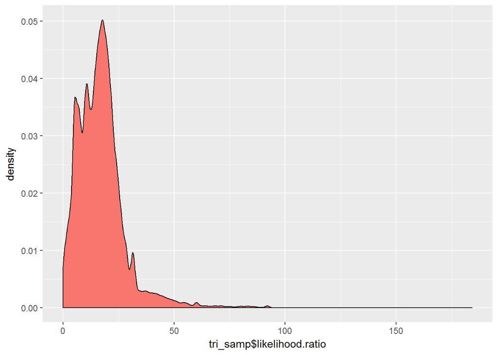

```
##
##  One-sample Kolmogorov-Smirnov test
##
## data:  unique(tri_samp$pmi)
## D = 0.024157, p-value = 3.159e-05
## alternative hypothesis: two-sided
```

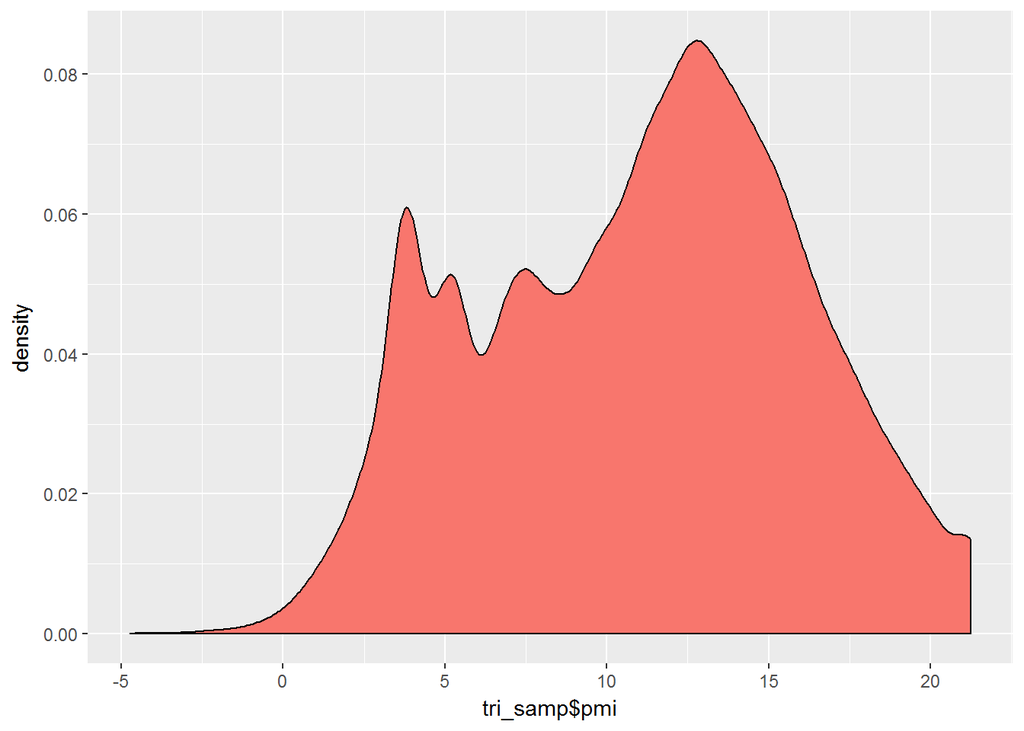

None of the variables is normally distributed, so we are using Kendall’s tau for correlation tests:

```
##
##  Kendall's rank correlation tau
##
## data:  tri_samp$frequency and tri_samp$pmi
## z = -26.23, p-value < 2.2e-16
## alternative hypothesis: true tau is not equal to 0
## sample estimates:
##         tau
## -0.09444552
```

```
##
##  Kendall's rank correlation tau
##
## data:  tri_samp$frequency and tri_samp$t.score
## z = 131.23, p-value < 2.2e-16
## alternative hypothesis: true tau is not equal to 0
## sample estimates:
##       tau
## 0.4723416
```

```
##
##  Kendall's rank correlation tau
##
## data:  tri_samp$frequency and tri_samp$likelihood.ratio
## z = 64.817, p-value < 2.2e-16
## alternative hypothesis: true tau is not equal to 0
## sample estimates:
##       tau
## 0.2332402
```

As we can see, the correlations ate present, but they are mostly weak. The weakest correlation is between frequency and PMI (also this is an inverse relation), the highest is between frequency and t score. We use linear regression to test if it is possible to predict frequency based on the correlation metrics. Since our metrix are quite complex, we use a polynomial regression model with a degree of 3.

```
##
## Call:
## lm(formula = tri_samp$frequency ~ poly(tri_samp$t.score, 3) +
##     poly(tri_samp$likelihood.ratio, 3) + poly(tri_samp$pmi, 3))
##
## Residuals:
##     Min      1Q  Median      3Q     Max
## -71.458  -0.236   0.008   0.239  73.851
##
## Coefficients:
##                                       Estimate Std. Error t value Pr(>|t|)
## (Intercept)                          1.307e+00  3.944e-03  331.48   <2e-16
## poly(tri_samp$t.score, 3)1           3.150e+02  1.063e+00  296.41   <2e-16
## poly(tri_samp$t.score, 3)2           2.941e+02  9.837e-01  299.01   <2e-16
## poly(tri_samp$t.score, 3)3           2.464e+02  9.640e-01  255.58   <2e-16
## poly(tri_samp$likelihood.ratio, 3)1 -1.353e+02  1.861e+00  -72.71   <2e-16
## poly(tri_samp$likelihood.ratio, 3)2  4.991e+01  1.362e+00   36.65   <2e-16
## poly(tri_samp$likelihood.ratio, 3)3  7.067e+01  1.118e+00   63.23   <2e-16
## poly(tri_samp$pmi, 3)1               4.863e+01  2.075e+00   23.43   <2e-16
## poly(tri_samp$pmi, 3)2               8.962e+01  1.006e+00   89.09   <2e-16
## poly(tri_samp$pmi, 3)3              -8.971e+01  9.611e-01  -93.34   <2e-16
##
## (Intercept)                         ***
## poly(tri_samp$t.score, 3)1          ***
## poly(tri_samp$t.score, 3)2          ***
## poly(tri_samp$t.score, 3)3          ***
## poly(tri_samp$likelihood.ratio, 3)1 ***
## poly(tri_samp$likelihood.ratio, 3)2 ***
## poly(tri_samp$likelihood.ratio, 3)3 ***
## poly(tri_samp$pmi, 3)1              ***
## poly(tri_samp$pmi, 3)2              ***
## poly(tri_samp$pmi, 3)3              ***
## ---
## Signif. codes:  0 '***' 0.001 '**' 0.01 '*' 0.05 '.' 0.1 ' ' 1
##
## Residual standard error: 0.8818 on 49990 degrees of freedom
## Multiple R-squared:  0.8545, Adjusted R-squared:  0.8544
## F-statistic: 3.261e+04 on 9 and 49990 DF,  p-value: < 2.2e-16
```

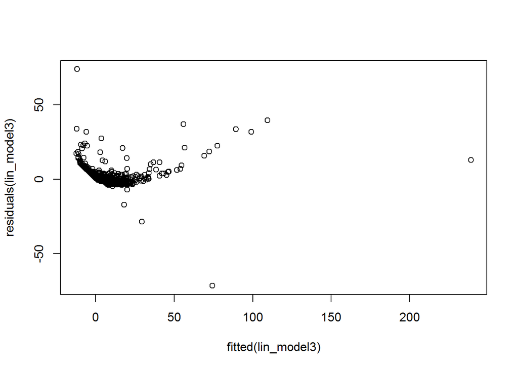

As can be seen, frequency can be predicted with all metrics, and the model seems to fit the data pretty well according to adjusted R-squared. However, plot of fitted vs. residuals shows a clear pattern. Newertheless, the model is significant, and its F-statistic is quite high. Overall, we can conclude, that frequency values can be predicted with collocation metrics, but not very accurately.

Now to the fivegrams.

#### Fivegrams (complete corpus list, sample size=50000)

[output not shown]

```
## 'data.frame':    50000 obs. of  8 variables:
##  $ X               : int  499647 990020 522976 335709 617728 238046 23705 772894 1065799 776299 ...
##  $ frequency       : num  2 1 1 1 1 1 1 1 1 1 ...
##  $ likelihood.ratio: num  26.87 18.63 5.98 6.97 9.08 ...
##  $ ngram           : Factor w/ 1197006 levels "- - -","- - ,",..: 390418 1018884 126604 178727 483072 617553 23626 693067 885034 658801 ...
##  $ pmi             : num  10.94 13.44 5.58 5.03 6.55 ...
##  $ raw.frequency   : num  8.08e-07 4.04e-07 4.04e-07 4.04e-07 4.04e-07 ...
##  $ t.score         : num  1.413 1 0.979 0.969 0.989 ...
##  $ tag             : Factor w/ 2218 levels "- - -","- - ,",..: 637 2084 485 1879 617 639 212 1704 1770 1737 ...
```

Normality tests:

```
##
##  One-sample Kolmogorov-Smirnov test
##
## data:  unique(five_samp$t.score)
## D = 0.36183, p-value < 2.2e-16
## alternative hypothesis: two-sided
```

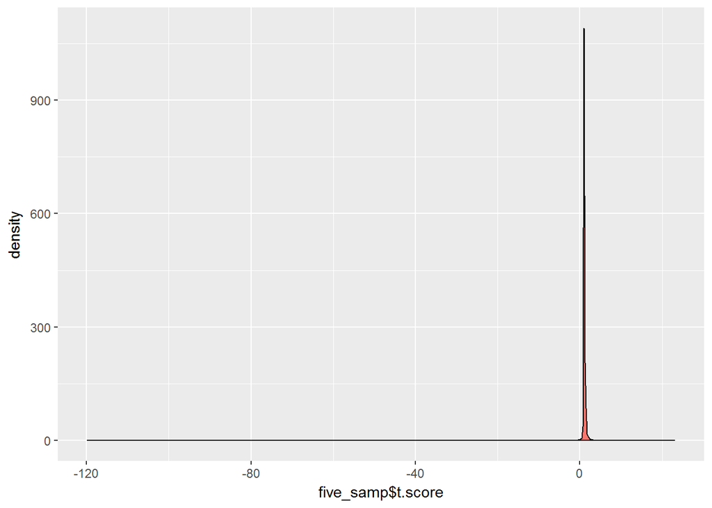

```
##
##  One-sample Kolmogorov-Smirnov test
##
## data:  unique(five_samp$likelihood.ratio)
## D = 0.20775, p-value < 2.2e-16
## alternative hypothesis: two-sided
```

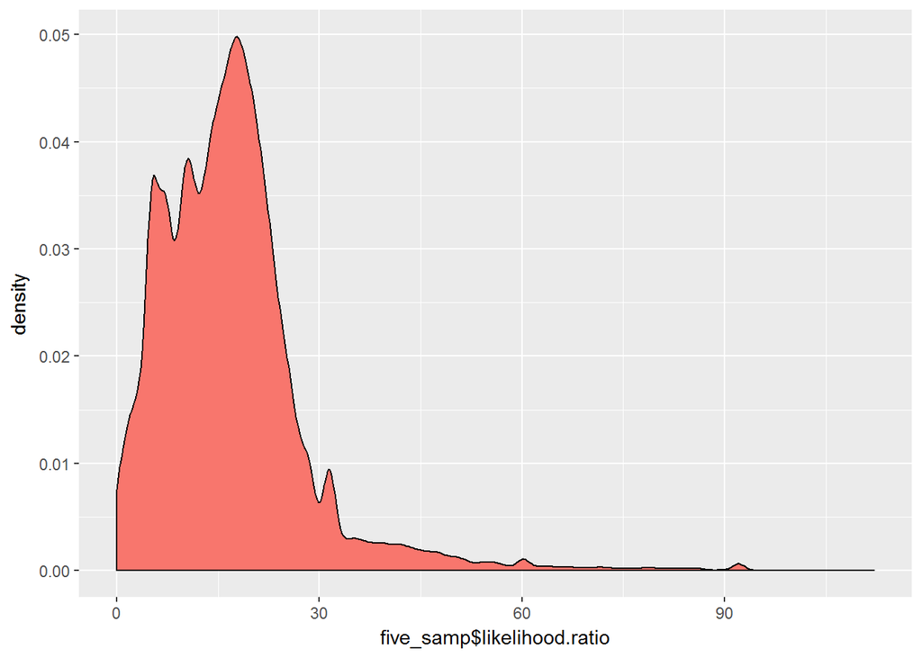

```
##
##  One-sample Kolmogorov-Smirnov test
##
## data:  unique(five_samp$pmi)
## D = 0.026024, p-value = 5.472e-06
## alternative hypothesis: two-sided
```

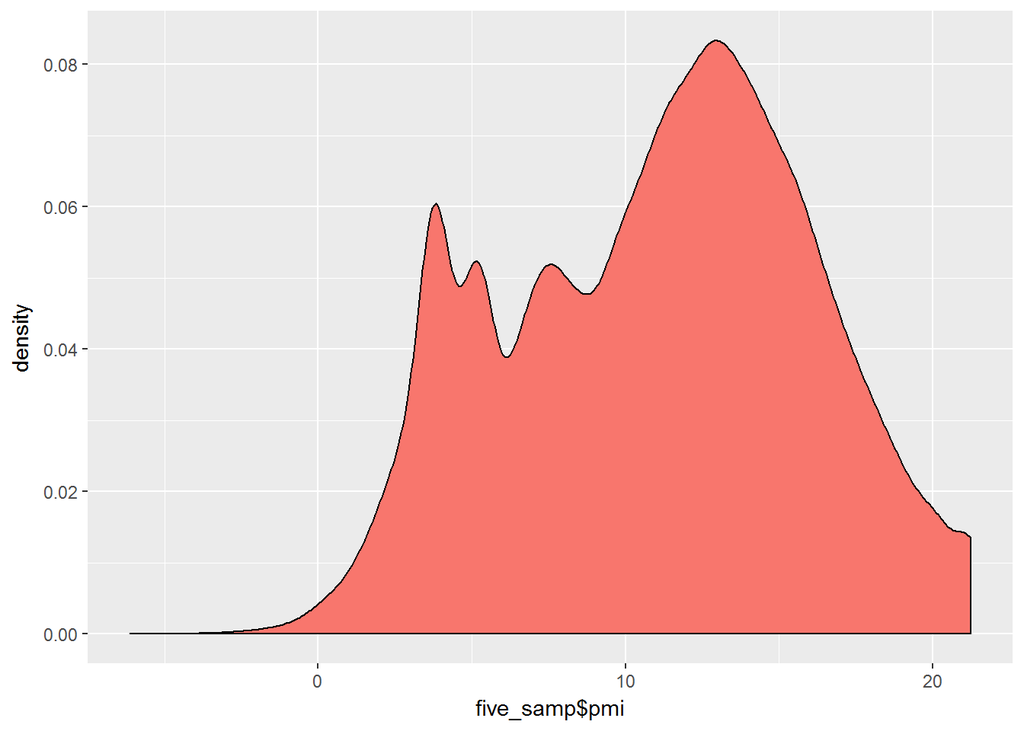

Correlations:

```
##
##  Kendall's rank correlation tau
##
## data:  five_samp$frequency and five_samp$pmi
## z = -24.631, p-value < 2.2e-16
## alternative hypothesis: true tau is not equal to 0
## sample estimates:
##         tau
## -0.08876053
```

```
##
##  Kendall's rank correlation tau
##
## data:  five_samp$frequency and five_samp$t.score
## z = 129.11, p-value < 2.2e-16
## alternative hypothesis: true tau is not equal to 0
## sample estimates:
##       tau
## 0.4650809
```

```
##
##  Kendall's rank correlation tau
##
## data:  five_samp$frequency and five_samp$likelihood.ratio
## z = 63.244, p-value < 2.2e-16
## alternative hypothesis: true tau is not equal to 0
## sample estimates:
##       tau
## 0.2277643
```

Again, none of the metrics is normally distributed and the correlations are about as high as in the previous experiment.

We will use the same polynomial regression formula as in the previous part.

```
##
## Call:
## lm(formula = five_samp$frequency ~ poly(five_samp$t.score, 3) +
##     poly(five_samp$likelihood.ratio, 3) + poly(five_samp$pmi,
##     3))
##
## Residuals:
##      Min       1Q   Median       3Q      Max
## -162.642   -0.391   -0.001    0.454  287.608
##
## Coefficients:
##                                        Estimate Std. Error t value
## (Intercept)                           1.312e+00  9.345e-03  140.43
## poly(five_samp$t.score, 3)1           3.835e+02  2.333e+00  164.39
## poly(five_samp$t.score, 3)2           5.363e+02  2.350e+00  228.20
## poly(five_samp$t.score, 3)3           4.225e+02  2.139e+00  197.51
## poly(five_samp$likelihood.ratio, 3)1 -3.363e+02  4.488e+00  -74.93
## poly(five_samp$likelihood.ratio, 3)2  4.404e+01  3.618e+00   12.17
## poly(five_samp$likelihood.ratio, 3)3  5.006e+00  2.797e+00    1.79
## poly(five_samp$pmi, 3)1               1.674e+02  5.316e+00   31.49
## poly(five_samp$pmi, 3)2               1.400e+02  2.661e+00   52.62
## poly(five_samp$pmi, 3)3              -1.744e+02  2.247e+00  -77.63
##                                      Pr(>|t|)
## (Intercept)                            <2e-16 ***
## poly(five_samp$t.score, 3)1            <2e-16 ***
## poly(five_samp$t.score, 3)2            <2e-16 ***
## poly(five_samp$t.score, 3)3            <2e-16 ***
## poly(five_samp$likelihood.ratio, 3)1   <2e-16 ***
## poly(five_samp$likelihood.ratio, 3)2   <2e-16 ***
## poly(five_samp$likelihood.ratio, 3)3   0.0735 .
## poly(five_samp$pmi, 3)1                <2e-16 ***
## poly(five_samp$pmi, 3)2                <2e-16 ***
## poly(five_samp$pmi, 3)3                <2e-16 ***
## ---
## Signif. codes:  0 '***' 0.001 '**' 0.01 '*' 0.05 '.' 0.1 ' ' 1
##
## Residual standard error: 2.09 on 49990 degrees of freedom
## Multiple R-squared:  0.679,  Adjusted R-squared:  0.679
## F-statistic: 1.175e+04 on 9 and 49990 DF,  p-value: < 2.2e-16
```

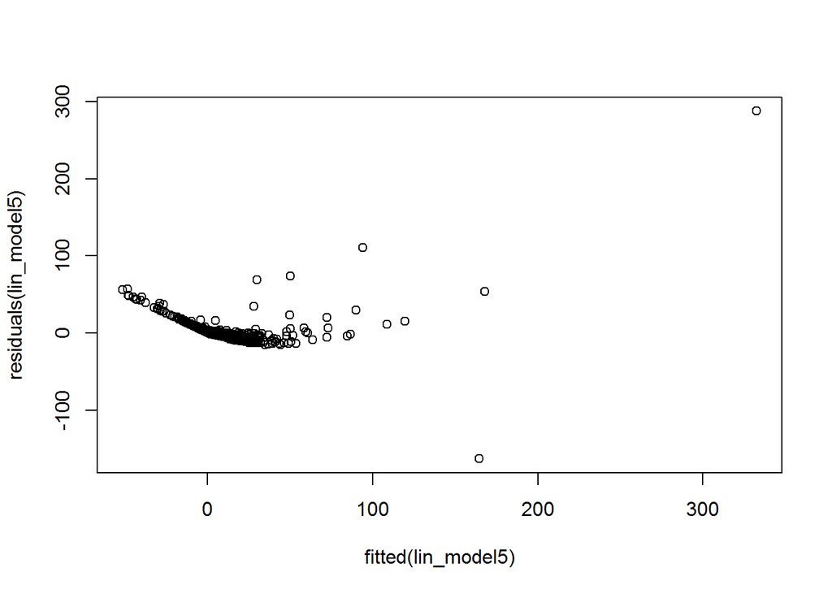

Now to question one.

### Question 1

To determine if the top ranked collocations are domain-specific or not, we first have to extract the most significant trigrams and fivegrams. We chose those which collocation metrics vere all higher than 75% (those from the first percentile). Then, we take intersections between those lists and domain-wise trigram and fivegram lists.

Here is the distribution of top ngrams by domains. History is relatively small, because it is a smaller domain that is currently in process of creation. We had 167517 top trigrams and 225742 top fivegrams. Note that domain-wise tops are interseptions between the overall tops and domain collocation lists.

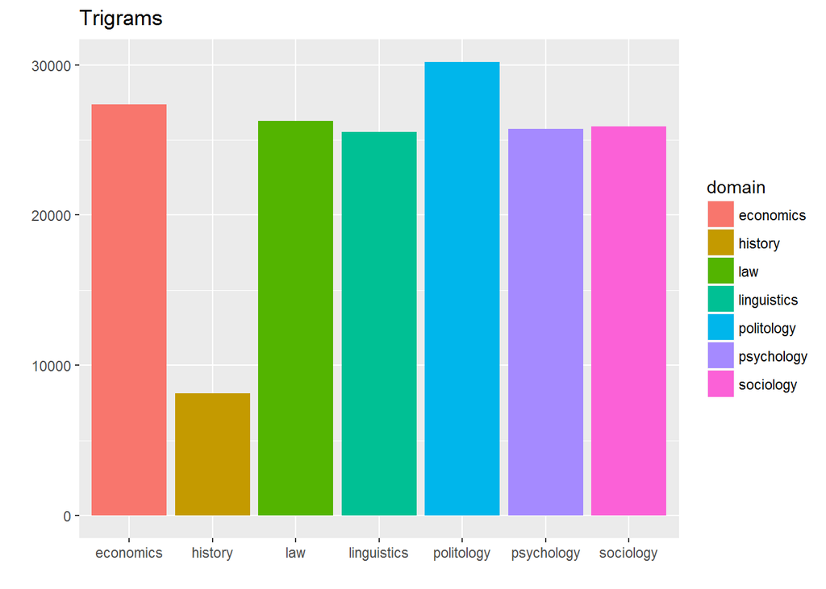

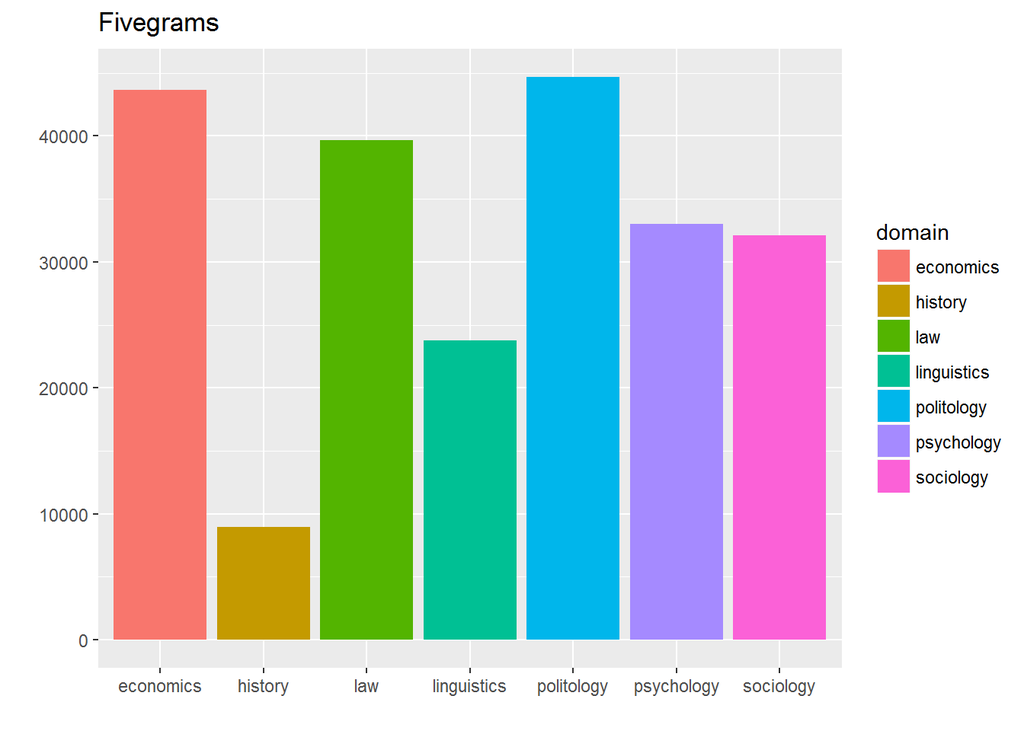

As can be seen, most of the popular ngrams are from economics and politology, and while for economics it is justifiable hence it is a larger domain, for politology it is quite surprising.

Let’s look how many ngrams domain-wise tops have in common. First, we checked how many shared and unique ngrams are there between domain tops.

Trigrams:

```
## [1] 1600
```

Fivegrams:

```
## [1] 72
```

Next, we looked if there are any top ngrams that are present in all domains. For fivegrams there were no such sequences (however, there was “как бы то ни было” that was present in all lists except for psychology), and for trigrams, the following 8 sequences were found:

```
## [1] "бы то ни"           "в конечном счете"   "в конце концов"
## [4] "в противном случае" "до сих пор"         "тем или иным"
## [7] "то ни было"         "точно так же"
```

Finally, let’s look how many top ngrams were shared by each domain pair (which is not so much in each case).

|  | history | law | linguistics | economics | politology | psychology | sociology |
| --- | --- | --- | --- | --- | --- | --- | --- |
| history | 8114 | 54 | 26 | 29 | 64 | 36 | 111 |
| law | 54 | 26267 | 60 | 162 | 237 | 90 | 148 |
| linguistics | 26 | 60 | 25523 | 62 | 61 | 77 | 60 |
| economics | 29 | 162 | 62 | 27377 | 164 | 145 | 140 |
| politology | 64 | 237 | 61 | 164 | 30202 | 125 | 245 |
| psychology | 36 | 90 | 77 | 145 | 125 | 25744 | 131 |
| sociology | 111 | 148 | 60 | 140 | 245 | 131 | 25890 |

|  | history | law | linguistics | economics | politology | psychology | sociology |
| --- | --- | --- | --- | --- | --- | --- | --- |
| history | 8938 | 6 | 2 | 1 | 3 | 1 | 17 |
| law | 6 | 39653 | 1 | 10 | 18 | 2 | 3 |
| linguistics | 2 | 1 | 23758 | 1 | 4 | 5 | 4 |
| economics | 1 | 10 | 1 | 43664 | 5 | 5 | 7 |
| politology | 3 | 18 | 4 | 5 | 44701 | 5 | 6 |
| psychology | 1 | 2 | 5 | 5 | 5 | 32985 | 4 |
| sociology | 17 | 3 | 4 | 7 | 6 | 4 | 32115 |

### Conclusions

We can conclude that, first, there is a correlation between collocation metrics and frequency, but this correlation, however present, is relatively weak. Second, top (most significant) collocations are different for each domain, with little to no collocations shared by all domains.